# Introduction to nimbleEcology

NIMBLE 2022 virtual EFI workshop

NIMBLE Development Team

April 2022

# nimbleEcology overview

The `nimbleEcology` package (Goldstein et al.) provides marginalized distributions that turn hierarchical structures with latent states into one line distributions similar to familiar distributions like dpois() or dbinom():

- Cormack-Jolly-Seber (CJS)
- Occupancy
- Dynamic occupancy
- N-mixture (with fast computation)
- Hidden Markov Models (e.g. multi-state and multi-event capture-recapture)

# Refresher on HMMs and latent states

- Model fitting, whether working with Bayesian or maximum likelihood tools, always involves calculating the likelihood of a model.
- In MLE, we often calculate the likelihood of a set of parameters given our data and numerically optimize those parameters to estimate the maximum of the likelihood function (MLE packages for ecological models like unmarked)
- In Bayesian statistics, we don’t directly optimize the likelihood, but we do calculate it for a set of parameters when deciding whether to accept a newly sampled value during MCMC sampling.
- In Hidden Markov Models (i.e., have latent states), calculating the likelihood becomes more complicated.
- We want to know the likelihood of our parameters, given the data and latent states
- In the dynamic occupany example we took a brute force approach and put samplers on the latent states. MCMC then algorithms sample from the posterior distribution of parameters and latent (unknown) states given the observed data, This can be *very* computationally costly.
- Limits research efficiency
- Limits research quality:
  - constrains the range of models that can be compared
  - limits potential for using simulations to check estimation performance, cross-validation, or other layers of computational analysis

# Why are marginalized distributions helpful?

- To sample the likelihood without sampling specific latent state values, you have to calculate and integrate over all possible values of each latent state
- This means writing a likelihood function that considers all possible latent states and computes the likelihood as a weighted sum across those (“marginalizing”, or “integrating out”)
- Summing over the latent states in a hidden Markov model for multi-state or multi-event capture–recapture can yield orders-of-magnitude improvement in computational efficiency [(Ponisio et al. 2020)](https://onlinelibrary.wiley.com/doi/full/10.1002/ece3.6053)[(Turek et al. 2016)](https://link.springer.com/article/10.1007/s10651-016-0353-z).

# Disadvantages of using marginalized distribution?

- Marginalizing vs. sampling: The winner depends on computational costs and mixing.
  - Dynamic occupancy and N-mixture can perform better with sampling (Ponisio et al. 2020).
- ‘derivied quantities’ such as calculating a posterior on the total number of occupied sites is not possible because we aren’t sampling the latent states

# Some resources

- The [`nimbleEcology` (Goldstein et al. 2020)](https://CRAN.R-project.org/package=nimbleEcology) package.
- We will focus on the code. For `nimbleEcology`, the math related to the code is summarized in the [package vignette](https://cran.r-project.org/web/packages/nimbleEcology/vignettes/Introduction_to_nimbleEcology.html).
- Examples of occupancy, dynamic occupancy, and N-mixture models are given in [*One size does not fit all: Customizing MCMC methods for hierarchical models using NIMBLE* (Ponisio et al. 2020)](https://onlinelibrary.wiley.com/doi/full/10.1002/ece3.6053).
- Examples of CJS and HMM are given in [*Efficient Markov chain Monte Carlo sampling for hierarchical hidden Markov models* (Turek et al. 2016)](https://link.springer.com/article/10.1007/s10651-016-0353-z).
- Ben Goldstein’s blog for more examples using [nimbleEcology](https://dochvam.github.io/blog.html)

# Each distribution comes in multiple versions.

Recall that `nimbleFunction`s require static typing.

Unfortunately:

- scalars are not automatically converted to length-one vectors.
- vectors are not automatically converted to single-row or single-column matrices.

This means we have implemented variants for each distribution.

# Dynamic occupancy

- dDynOcc_s$**$ functions take time-independent (scalar) persistence probabilities, while
- dDynOcc_v$**$functions take time-dependent (vector) persistence probabilities
- dDynOcc_$*$s$*$ functions take time-independent (scalar) colonization probabilities, while
- dDynOcc_$*$v$*$functions take time-dependent (vector) colonization probabilities
- dDynOcc_$**$s functions take time-independent (scalar) observation probabilities, while
- dDynOcc_$**$v functions take observation probabilities dependent on time step (vector) and
- dDynOcc_$**$m functions take observation probabilities dependent on both time step and observation event (matrix)

# Back to our dynamic (single species multi season) occupancy model

```r
set.seed(444)

# simulate a time-constant model with 3 different covariates affecting the 3 parameters (phi, gamma, p)

occ.data <- AHMbook::simDynocc(
  nsites = 250,
  nyears = 10,
  nsurveys = 3,
  mean.psi1 = 0.6, # average occupancy probability in first year
  beta.Xpsi1 = 0, # coefficient of environ covariate in p(initial occupancy).
  range.phi = c(0.7, 0.7), # bounds of uniform distribution from which annual p(persistence) is randomly drawn.
  beta.Xphi = 1, # coefficients of environ covariate in p(persistence).
  range.gamma = c(0.3, 0.3), # bounds of uniform distribution from which annual p(colonization) is randomly drawn.
  beta.Xgamma = 1, # coefficient of environmental covariate in p(colonization).
  range.p = c(0.5, 0.5), # bounds of uniform distribution from which annual p(detection) is randomly drawn.
  beta.Xp = 1, # coefficient of environmental covariate in p(detection).
  show.plot = FALSE)

## constants
dOcc_constants <- list(nsite = occ.data$nsites,
                  nsurvey = occ.data$nsurveys,
                  nyear = occ.data$nyears,
                  start = rep(1, occ.data$nyears), ## new
                  end = rep(occ.data$nsurveys, occ.data$nyears)) ## new

## data (NO ZS!)
dOcc_data <- list(y = occ.data$y,
                    Xphi = occ.data$Xphi,
                    Xgamma = occ.data$Xgamma,
                    Xp = occ.data$Xp)

## initial conditions (NO ZS!)
dOcc_inits <- list(psi1 = runif(1, 0, 1),
       beta = runif(6, -4, 4))
```

# The dynamic occupancy model with marginalization

```r
dOcc_code <- nimbleCode({
  for (site in 1:nsite) {
    for (year in 1:nyear) {

      ## persistence
      logit(phi[site, year]) <- beta[1] + beta[2] * Xphi[site, year]

      ## colonization
      logit(gamma[site, year]) <- beta[3] + beta[4] * Xgamma[site, year]

      ## detection
      for (survey in 1:nsurvey) {
        logit(p[site, survey, year]) <- beta[5] + beta[6] * Xp[site, survey, year]
      }
    }
    ## Marginalization
    ## the probability of all reps over all years for one site.
    y[site, 1:nsurvey,  1:nyear] ~ dDynOcc_vvm(psi1, phi[site, 1:nyear],
                                              gamma[site, 1:nyear],
                                              p[site, 1:nsurvey, 1:nyear],
                                 start[1:nyear], end[1:nyear])
  }
  # priors
  psi1 ~ dunif(0, 1)
  for (i in 1:4) {
    beta[i] ~ dnorm(0, 1.0e-2)
  }
})
```

# 1. Create a model

```r
dOcc_model <- nimbleModel(code = dOcc_code,
                          constants = dOcc_constants,
                          data = dOcc_data,     # data can be set later.
                          inits = dOcc_inits  # inits can be set later.
                          )
```

```
## Defining model
```

```
## Building model
```

```
## Setting data and initial values
```

```
## Running calculate on model
##   [Note] Any error reports that follow may simply reflect missing values in model variables.
```

```
## Checking model sizes and dimensions
```

# 2. Create an MCMC

```r
dOcc_MCMCconf <- configureMCMC(dOcc_model)
```

```
## ===== Monitors =====
## thin = 1: beta, psi1
## ===== Samplers =====
## RW sampler (5)
##   - psi1
##   - beta[]  (4 elements)
```

```r
dOcc_MCMC <- buildMCMC(dOcc_MCMCconf)
```

## 3. Compile the model and MCMC

```r
C_dOcc_model <- compileNimble(dOcc_model) # These two lines can be done in one line.
```

```
## Compiling
##   [Note] This may take a minute.
##   [Note] Use 'showCompilerOutput = TRUE' to see C++ compilation details.
```

```r
C_dOcc_MCMC <- compileNimble(dOcc_MCMC, project = dOcc_model)
```

```
## Compiling
##   [Note] This may take a minute.
##   [Note] Use 'showCompilerOutput = TRUE' to see C++ compilation details.
```

## 4. Run the MCMC

```r
samples <- runMCMC(C_dOcc_MCMC, niter = 10000,
                   samplesAsCodaMCMC = TRUE,
                   nburnin = 1000,
                   nchains=3)
```

```
## Running chain 1 ...
```

```
## |-------------|-------------|-------------|-------------|
## |-------------------------------------------------------|
```

```
## Running chain 2 ...
```

```
## |-------------|-------------|-------------|-------------|
## |-------------------------------------------------------|
```

```
## Running chain 3 ...
```

```
## |-------------|-------------|-------------|-------------|
## |-------------------------------------------------------|
```

```r
summary(samples)
```

```
##
## Iterations = 1:9000
## Thinning interval = 1
## Number of chains = 3
## Sample size per chain = 9000
##
## 1. Empirical mean and standard deviation for each variable,
##    plus standard error of the mean:
##
##             Mean      SD  Naive SE Time-series SE
## beta[1]  0.97971 0.12761 0.0007766      0.0016199
## beta[2]  0.12050 0.11291 0.0006872      0.0014708
## beta[3] -0.33979 0.14583 0.0008875      0.0018198
## beta[4]  0.03256 0.13420 0.0008167      0.0017069
## beta[5]  3.26655 0.00000 0.0000000      0.0000000
## beta[6]  0.78015 0.00000 0.0000000      0.0000000
## psi1     0.62710 0.03073 0.0001870      0.0003869
##
## 2. Quantiles for each variable:
##
##            2.5%      25%      50%     75%   97.5%
## beta[1]  0.7327  0.89266  0.97976  1.0661  1.2339
## beta[2] -0.1005  0.04549  0.11973  0.1966  0.3393
## beta[3] -0.6264 -0.43662 -0.33825 -0.2415 -0.0526
## beta[4] -0.2282 -0.05775  0.03337  0.1238  0.2907
## beta[5]  3.2666  3.26655  3.26655  3.2666  3.2666
## beta[6]  0.7802  0.78015  0.78015  0.7802  0.7802
## psi1     0.5670  0.60620  0.62725  0.6479  0.6867
```

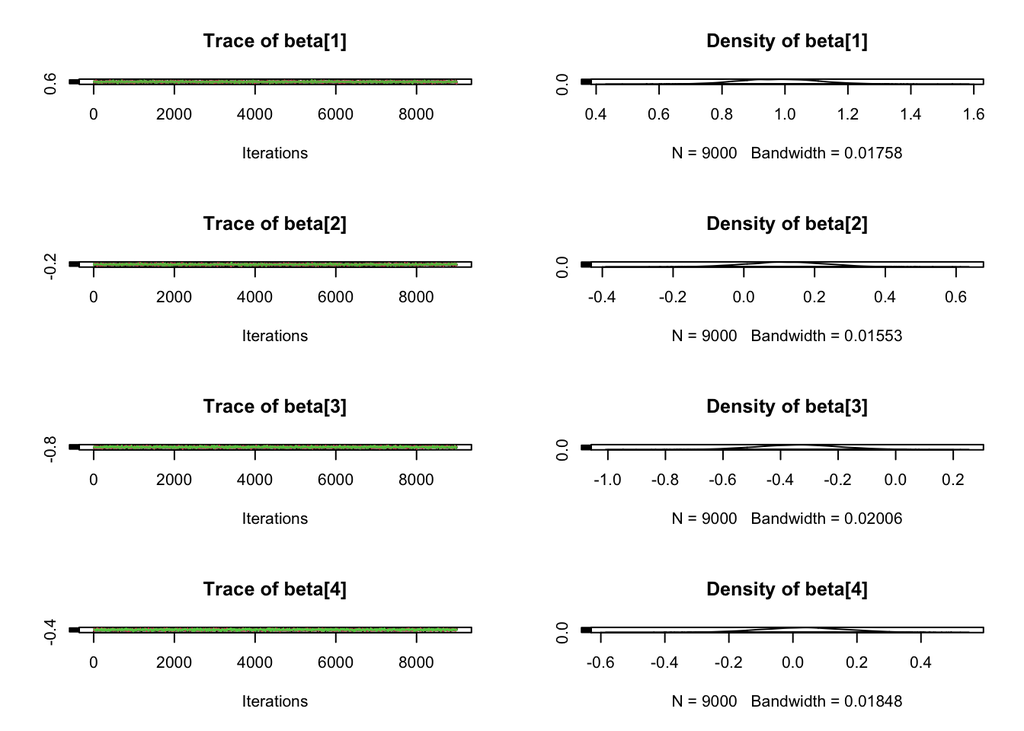

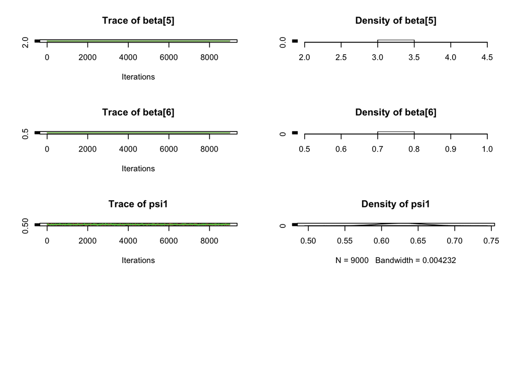

```r
plot(samples)
```